# Assignment 1 — Bivariate Regression and Residuals (OECD Welfare State Data)

# Introduction

A central proposition in comparative welfare-state scholarship holds that partisan political configurations exert systematic influence on the scope and redistributive character of social policy regimes (Iversen and Stephens 2008). Specifically, the power resources theory suggests that left- and labor-party representatives, representing working-class constituencies, advocate for more extensive social protections precisely because such decommodifying programs, defined as policies that reduce individuals’ dependence on labor-market participation for securing basic welfare, disproportionately benefit their core electoral base (Bambra 2007). This theoretical framework implies that nations with greater left-party representation in government should exhibit higher levels of welfare-state decommodification. Building on this theoretical foundation, the present analysis empirically evaluates this proposition utilizing cross-national OECD data, examining whether left government representation significantly predicts variation in decommodification across advanced industrial democracies.

# Research question and hypothesis

Research Question: To what extent does left/labor government representation predict welfare state decommodification across OECD member states? This research question is operationalized through a bivariate regression specification that directly corresponds to the following formal hypothesis test: * Null hypothesis (H0): Left government representation is unrelated to decommodification ($β₁ = 0$). * Alternative hypothesis (H1): Greater left representation is associated with higher decommodification ($β₁ > 0$).

# Data

The OECD dataset includes four variables: * decom (Decommodification): An index measuring welfare state development; higher values indicate more egalitarian welfare states. * left (Left-party representation): The share of legislative and cabinet seats held by left parties. * GDP: GDP per capita (in thousands of dollars). * gt65: Percent of the population aged 65 and older. In this context, the present analysis specifies decom as the dependent variable and left as the independent variable. While GDP and gt65 are theoretically plausible determinants of welfare state development, this study adopts a parsimonious bivariate specification to provide an initial empirical assessment of the partisan politics hypothesis. This approach enables a focused examination of the core relationship before incorporating additional control variables in subsequent multivariate models.

# Methods

I estimate a bivariate ordinary least squares (OLS) regression:
$$decom_i = \beta_0 + \beta_1(left_{i} +
\epsilon_{i}$$
where $\beta_0$ is the intercept (expected decommodification when left = 0), $beta_1$ captures the expected change in decommodification for a one-unit increase in left representation, and $\epsilon_{i}$ is the country-specific error term. Model fit is assessed using R² and the overall F-test, and residuals are examined to identify countries that are well explained by the model versus those poorly explained.

# Analysis

## Setup

```r
# Load the OECD Welfare State Data
df <- read_csv("~/SOCI_V 514 201 2025W2/Homework/Data/oecd.csv")
df
```

```
## # A tibble: 18 × 5
##    country     decom  left  gt65   gdp
##    <chr>       <dbl> <dbl> <dbl> <dbl>
##  1 Australia    13     1.7   9.6 10.1
##  2 Austria      31.1   7.6  15.4 10.3
##  3 Belgium      32.4   1.6  14.4 11.8
##  4 Canada       22     0     9.5 10.6
##  5 Denmark      38.1   5.3  14.4 13.0
##  6 Finland      29.2   3.8  12   10.4
##  7 France       27.5   1    13.9 12.1
##  8 Germany      27.7   5.5  15.5 13.3
##  9 Ireland      23.3   0.4  10.7  5.19
## 10 Italy        24.1   0.7  12.9  6.91
## 11 Japan        27.1   0     9    8.87
## 12 Nlands       32.4   1.3  11.5 11.9
## 13 NZ           17.1   1.7   9.7  7.44
## 14 Norway       38.3   5.3  14.8 14.0
## 15 Sweden       39.1   6.5  16.1 14.8
## 16 Switzerland  29.8   1.5  13.7 15.9
## 17 UK           23.4   6.3  14.9  9.34
## 18 USA          13.8   0    11.3 11.4
```

```r
# data cleaning
df <- df %>%
mutate(
decom = as.numeric(decom),
left = as.numeric(left)
)
df
```

```
## # A tibble: 18 × 5
##    country     decom  left  gt65   gdp
##    <chr>       <dbl> <dbl> <dbl> <dbl>
##  1 Australia    13     1.7   9.6 10.1
##  2 Austria      31.1   7.6  15.4 10.3
##  3 Belgium      32.4   1.6  14.4 11.8
##  4 Canada       22     0     9.5 10.6
##  5 Denmark      38.1   5.3  14.4 13.0
##  6 Finland      29.2   3.8  12   10.4
##  7 France       27.5   1    13.9 12.1
##  8 Germany      27.7   5.5  15.5 13.3
##  9 Ireland      23.3   0.4  10.7  5.19
## 10 Italy        24.1   0.7  12.9  6.91
## 11 Japan        27.1   0     9    8.87
## 12 Nlands       32.4   1.3  11.5 11.9
## 13 NZ           17.1   1.7   9.7  7.44
## 14 Norway       38.3   5.3  14.8 14.0
## 15 Sweden       39.1   6.5  16.1 14.8
## 16 Switzerland  29.8   1.5  13.7 15.9
## 17 UK           23.4   6.3  14.9  9.34
## 18 USA          13.8   0    11.3 11.4
```

## Descriptive statistics

```r
desc <- summary(df[, c("decom", "left")])
kable(desc, caption = "Table 1. Descriptive statistics") %>%
kableExtra::kable_styling(full_width = TRUE)
```

Table 1. Descriptive statistics

|  | decom | left |
| --- | --- | --- |
|  | Min. :13.00 | Min. :0.000 |
|  | 1st Qu.:23.32 | 1st Qu.:0.775 |
|  | Median :27.60 | Median :1.650 |
|  | Mean :27.19 | Mean :2.789 |
|  | 3rd Qu.:32.08 | 3rd Qu.:5.300 |
|  | Max. :39.10 | Max. :7.600 |

## Bivariate Regression Modeling

```r
m1 <- lm(decom ~ left, data = df)
# Model output
summary(m1)
```

```
##
## Call:
## lm(formula = decom ~ left, data = df)
##
## Residuals:
##      Min       1Q   Median       3Q      Max
## -12.4314  -3.8619   0.3309   5.6139   7.6142
##
## Coefficients:
##             Estimate Std. Error t value Pr(>|t|)
## (Intercept)  22.6877     2.3496   9.656 4.46e-08 ***
## left          1.6140     0.6249   2.583     0.02 *
## ---
## Signif. codes:  0 '***' 0.001 '**' 0.01 '*' 0.05 '.' 0.1 ' ' 1
##
## Residual standard error: 6.686 on 16 degrees of freedom
## Multiple R-squared:  0.2943, Adjusted R-squared:  0.2502
## F-statistic: 6.672 on 1 and 16 DF,  p-value: 0.02002
```

```r
## Tidy model output
tab <- broom::tidy(m1) %>%
mutate(
estimate = round(estimate, 4),
std.error = round(std.error, 4),
statistic = round(statistic, 3),
p.value = signif(p.value, 3)
)

fit <- broom::glance(m1) %>%
transmute(
n = nobs,
r2 = round(r.squared, 4),
adj_r2 = round(adj.r.squared, 4),
rmse = round(sigma, 4),
f_stat = round(statistic, 3),
f_p = signif(p.value, 3)
)

kable(tab, caption = "Table 1. OLS regression predicting decommodification from left party representation") %>%
kableExtra::kable_styling(full_width = FALSE)
```

Table 1. OLS regression predicting decommodification from left party representation

| term | estimate | std.error | statistic | p.value |
| --- | --- | --- | --- | --- |
| (Intercept) | 22.6877 | 2.3496 | 9.656 | 0.00 |
| left | 1.6140 | 0.6249 | 2.583 | 0.02 |

## Data Visualization

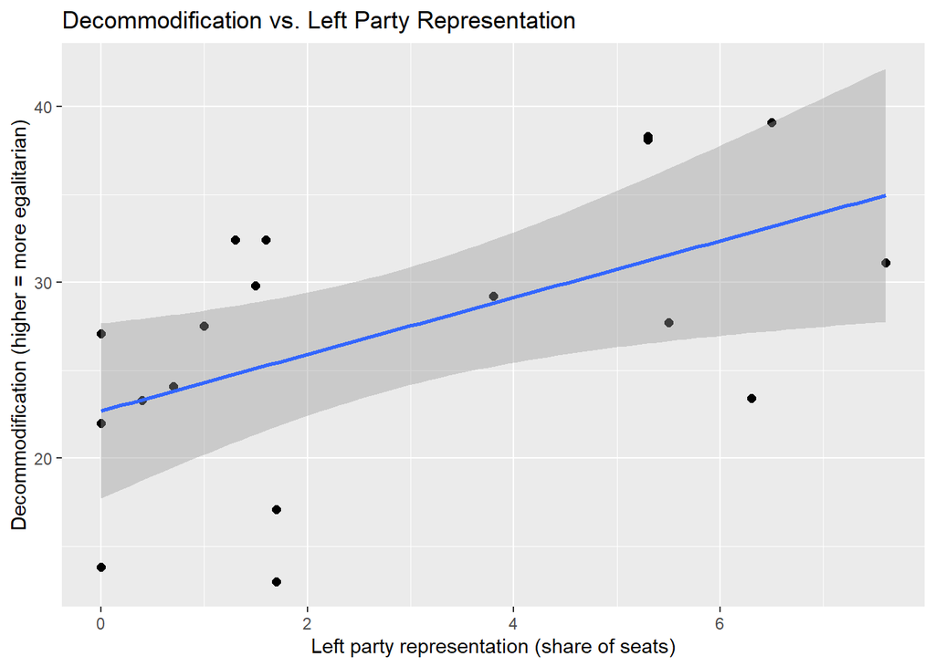

```r
## Scatterplot with regression line
p <- ggplot(df, aes(x = left, y = decom)) +
geom_point(size = 2) +
geom_smooth(method = "lm", se = TRUE) +
labs(
title = "Decommodification vs. Left Party Representation",
x = "Left party representation (share of seats)",
y = "Decommodification (higher = more egalitarian)"
)

p
```

# Results The regression results indicate a positive, statistically significant association between left-party representation and welfare-state decommodification. The estimated regression equation is:
$$\widehat{decom} = 22.6877 + 1.6140(left)$$
The intercept shows the predicted decommodification score when the left party representation is zero. This number acts as a reference point, not the main theoretical focus. The estimate is precise and statistically significant (p < 0.001). The slope coefficient is the main result of interest. It shows that countries with greater left- or labor-party representation have higher levels of decommodification. A one-unit increase in left government representation predicts a 1.614-point increase in decommodification, holding all else constant. The p-value (0.02) shows this is statistically significant at the 0.05 level. Therefore, we reject the null hypothesis of no relationship. Next, I assess model fit and the overall statistical significance of the regression results. The model explains about 29% of the variation in decommodification across countries: $R^2$ = 0.2943 (adjusted $R^2$ = 0.2502). Left government representation alone accounts for about 29% of the variance in decommodification in this OECD sample. This means that while partisan composition matters, most variation comes from other factors. The overall F-test confirms the model’s significance: F(1,16) = 6.672, p = 0.02002.

# Residual analysis

To further contextualize these results, I examine the dispersion of the residuals. Residuals range from -12.4314 to +7.6142, and the standard error is 6.686 (df = 16). This range shows that, even though the average link is significant, countries differ substantially from the fitted line. This means that left government representation does not equally well predict decommodification across all countries.

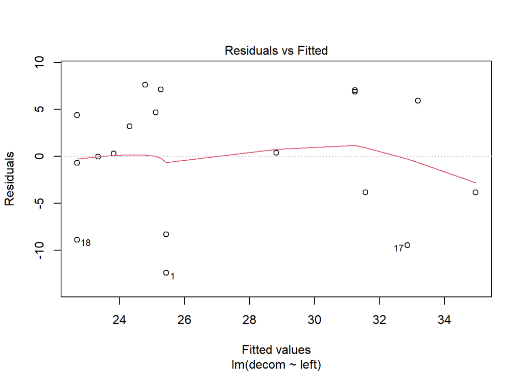

```r
plot(m1, which = 1) # residuals vs fitted
```

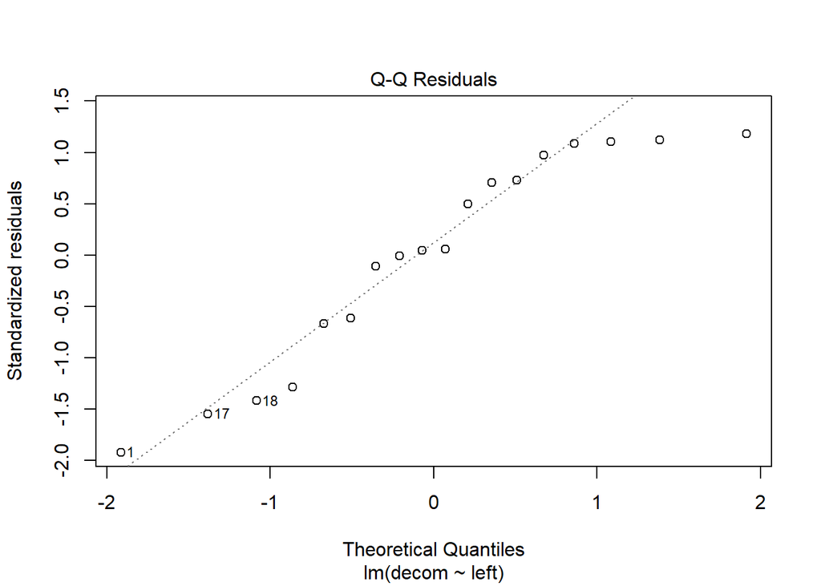

```r
plot(m1, which = 2) # normal Q-Q
```

The scatterplot with the fitted regression line backs up the statistical findings. Decommodification rises with left government representation, but there’s a lot of spread around the line. To check model performance in detail, I look at residuals for individual countries.
$$e_i = decom_i - \widehat{decom}_i$$
Nations exhibiting residuals proximate to zero are located near the regression line, indicating that left government representation constitutes a relatively robust predictor of decommodification in these contexts. Conversely, countries characterized by large absolute residuals deviate substantially from the fitted line, suggesting that left representation possesses limited explanatory power in these cases and that alternative factors likely exert dominant influence over welfare state outcomes.

```r
res_summary <- summary(resid(m1))
res_mat <- as.matrix(res_summary)
kable(res_mat, caption = "Table 2. Summary statistics of residuals from bivariate regression model") %>%
kableExtra::kable_styling(full_width = FALSE)
```

Table 2. Summary statistics of residuals from bivariate regression model

| Min. | -12.4314378 |
| --- | --- |
| 1st Qu. | -3.8619260 |
| Median | 0.3308701 |
| Mean | 0.0000000 |
| 3rd Qu. | 5.6139129 |
| Max. | 7.6141565 |

```r
df_res <- df %>%
mutate(
fitted = fitted(m1),
resid = resid(m1),
abs_resid = abs(resid),
std_resid = rstandard(m1)
) %>%
arrange(desc(abs_resid))

# Countries where left predicts decom well (small residuals)
best_fit <- df_res %>% arrange(abs_resid) %>% select(country, left, decom, fitted, resid, std_resid) %>% head(6)

# Countries where left predicts decom poorly (large residuals)
worst_fit <- df_res %>% select(country, left, decom, fitted, resid, std_resid) %>% head(6)

kable(best_fit, caption = "Countries where left party representation predicts decommodification well") %>% kableExtra::kable_styling(full_width = TRUE)
```

Countries where left party representation predicts decommodification well

| country | left | decom | fitted | resid | std_resid |
| --- | --- | --- | --- | --- | --- |
| Ireland | 0.4 | 23.3 | 23.33326 | -0.0332563 | -0.0052587 |
| Italy | 0.7 | 24.1 | 23.81745 | 0.2825479 | 0.0443885 |
| Finland | 3.8 | 29.2 | 28.82081 | 0.3791922 | 0.0586350 |
| Canada | 0.0 | 22.0 | 22.68766 | -0.6876621 | -0.1098547 |
| France | 1.0 | 27.5 | 24.30165 | 3.1983522 | 0.4996710 |
| Austria | 7.6 | 31.1 | 34.95395 | -3.8539535 | -0.6690276 |

```r
kable(worst_fit, caption = "Countries where left party representation predicts decommodification poorly") %>% kableExtra::kable_styling(full_width = TRUE)
```

Countries where left party representation predicts decommodification poorly

| country | left | decom | fitted | resid | std_resid |
| --- | --- | --- | --- | --- | --- |
| Australia | 1.7 | 13.0 | 25.43144 | -12.431438 | -1.923757 |
| UK | 6.3 | 23.4 | 32.85577 | -9.455772 | -1.546021 |
| USA | 0.0 | 13.8 | 22.68766 | -8.887662 | -1.419813 |
| NZ | 1.7 | 17.1 | 25.43144 | -8.331438 | -1.289284 |
| Nlands | 1.3 | 32.4 | 24.78584 | 7.614156 | 1.184007 |
| Belgium | 1.6 | 32.4 | 25.27004 | 7.129961 | 1.104534 |

# Conclusion

This analysis shows that left- or labor-party representation is positively linked to decommodification across the OECD. The bivariate regression finds a statistically significant positive slope (β₁ = 1.6140, p = 0.02) and overall model significance (F = 6.672, p = 0.02002). Left representation alone explains about 29% of the variance, a meaningful but incomplete association. Notwithstanding these findings, the residual analysis reveals important limitations of the parsimonious partisan explanation. Multiple national cases exhibit substantial deviations from model predictions, demonstrating that left representation has strong predictive validity in certain institutional contexts but limited explanatory power in others. These systematic residual patterns strongly indicate the need for subsequent multivariate specifications that incorporate additional theoretically salient determinants of decommodification—particularly GDP per capita and demographic aging (gt65) —alongside institutional and historical variables unavailable in the present dataset. In sum, the empirical evidence corroborates the theoretical claim that partisan political configurations constitute a significant determinant of welfare state egalitarianism, while simultaneously demonstrating that partisan effects operate contingently within a broader constellation of political-economic and institutional factors that condition welfare state development across advanced democracies.

# References

Bambra, C. 2007. “Going beyond The Three Worlds of Welfare Capitalism: Regime Theory and Public Health Research: Table 1.” Journal of Epidemiology and Community Health 61(12):1098–1102. doi:10.1136/jech.2007.064295. Iversen, Torben, and John D. Stephens. 2008. “Partisan Politics, the Welfare State, and Three Worlds of Human Capital Formation.” Comparative Political Studies 41(4–5):600–637. doi:10.1177/0010414007313117.